# Lecture 13

# Social Network Analysis 社群網路分析

## Nodes and Edges

SNA由nodes和edges組成的圖形結構(graph)。

The entities are referred to as **nodes** (or **vertices**, **actors**) (資料節點) of a graph, while the connections are **edges** (or **links**, **ties**, **relations**) (邊).

If the distinction between source and target is meaningful, the network is directed. If the distinction is not meaningful, the network is undirected.

根據edge是否具有「方向性」，可以將Graph分成「directed graph(有向圖)」與「undirected graph(無向圖)」

## 表示法

Adjacency Matrix(相鄰矩陣)：一個二維矩陣，若從vertex(A)到vertex(B)有edge，則矩陣位置[A][B]值為1，反之，則為0

Adjacency List(相鄰串列)：先以一個一維陣列列出所有的vertex，再以Linked list表示所有與vertex相連的vertex。

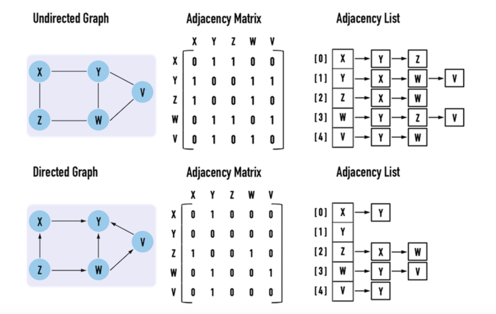

Reference: http://alrightchiu.github.io/SecondRound/graph-introjian-jie.html

### sociomatrix & edge list

- sociomatrix

將所有的node之間的關係用一個matrix來記錄，row代表是starting node，column代表是receiving node。

```
##      [,1] [,2] [,3] [,4] [,5]
## [1,]    0    1    1    0    0
## [2,]    0    0    1    1    0
## [3,]    0    1    0    0    0
## [4,]    0    0    0    0    0
## [5,]    0    0    1    0    0
```

- edge list

直接記錄每個paired的關係，第一個column代表是starting node，第二個column則是receiving node

```
##      [,1] [,2]
## [1,]    1    2
## [2,]    1    3
## [3,]    2    3
## [4,]    2    4
## [5,]    3    2
## [6,]    5    3
```

Note: attribute (屬性): 變數，可在加一個column表示weight，

## 應用

針對客戶及組織的網絡關係結構所做的研究與分析。社群網絡中的節點通常為客戶或是組織，透過不同種類關係連結串成網絡。節點間的連結之定義具有彈性，可以包含基本資料，如地址、電話、親屬關係，以及交易行為如:金融轉帳、業務關係、保單關係、理賠資料等。

- 金融保險詐欺偵測

從眾多案件中，分析那些是可疑案件，以及可疑的集團(群組)，自動展開各種關聯圖，節省人工調查的時間。

- 客戶行銷分析

利用社群關係的定義，將所有客戶依其網絡關係進行分組，創造出更準確的客戶分群模式。同時，可以找出群體中的領導者(Leader)，針對領導者設計行銷活動以創造更高的行銷報酬率，或是挽留領導者以降低客戶流失率。

# Visualize

Ref: http://pablobarbera.com/big-data-upf/html/02a-networks-intro-visualization.html

Ref: http://www.sthda.com/english/articles/33-social-network-analysis/136-network-analysis-and-manipulation-using-r/

Packages: `library(igraph)`